# Hands-On CRM

30/03/2019

## Lesson Plan

- Fundamentals (30 mins)
- `dfcrm` package (45 mins)
- Mathematics behind the scene (30 mins)

## CRM Fundamentals

## Introduction

The CRM iteratively changes dose, seeking some acceptable target probability of toxicity, \(Prob(DLT)\).

It uses a statistical model to perform an equivalent job to 3+3.

CRM and 3+3 **only make sense** under the expectation that a higher dose will be better for the patient.

## Vital Ingredients

Two critical pieces:

- `skeleton` is the prior guess of \(Prob(DLT)\) at each dose
- `target` is the desired \(Prob(DLT)\)

E.g.

```r
skeleton = c(0.1, 0.15, 0.25, 0.35, 0.5)
target = 0.25
```

## `skeleton`

- Strictly increasing (aka *monotonically* increasing)

```r
num_doses = length(skeleton)
dose_data = data.frame(Dose = 1:num_doses, ProbDLT = skeleton, Belief = 'Prior')
kable(dose_data)
```

| Dose | ProbDLT | Belief |
| --- | --- | --- |
| 1 | 0.10 | Prior |
| 2 | 0.15 | Prior |
| 3 | 0.25 | Prior |
| 4 | 0.35 | Prior |
| 5 | 0.50 | Prior |

## `skeleton`

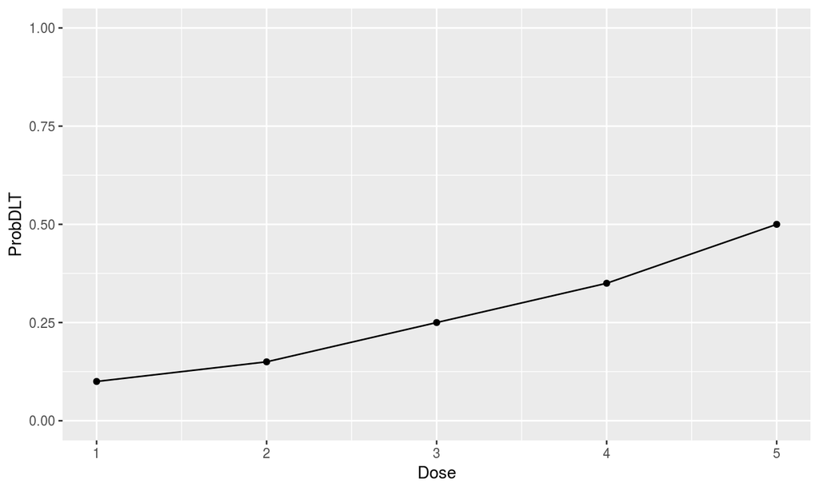

```r
library(ggplot2)
ggplot(dose_data, aes(x = Dose, y = ProbDLT)) +
  geom_point() + geom_line() + ylim(0, 1)
```

## `target`

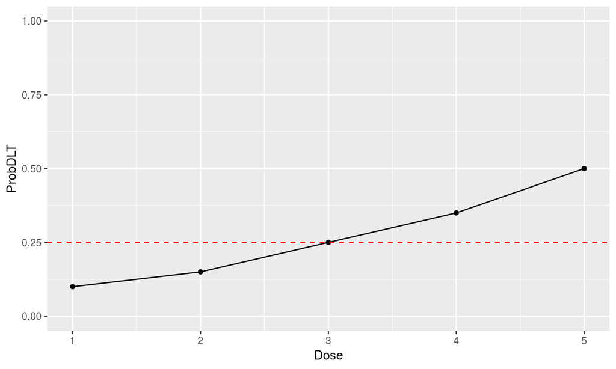

```r
ggplot(dose_data, aes(x = Dose, y = ProbDLT)) +
  geom_point() + geom_line() + ylim(0, 1) +
  geom_hline(yintercept = target, linetype = 'dashed', col = 'red')
```

- Where `target` intersects the \(Prob(DLT)\) curve is the recommended dose.
- In reality, we usually avoid skipping untested doses.

## CRM slides the skeleton up & down

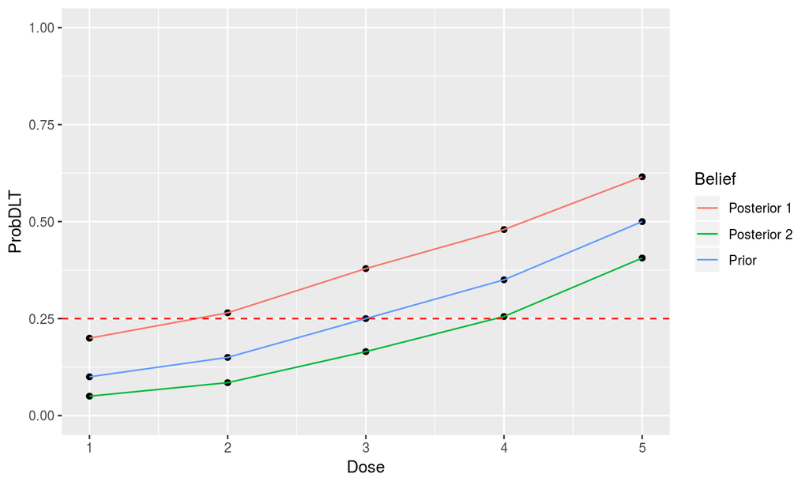

## How does CRM slide the skeleton?

```r
skeleton
```

```
## [1] 0.10 0.15 0.25 0.35 0.50
```

```r
skeleton^0.7
```

```
## [1] 0.1995262 0.2650110 0.3789291 0.4795652 0.6155722
```

```r
skeleton^1.3
```

```
## [1] 0.05011872 0.08490214 0.16493849 0.25543974 0.40612620
```

## A workable model

Raising the skeleton to a power raises and lowers it…

… depending on whether the power is >1 or <1.

… But what happens when the power is < 0?

## Task

What happens to `skeleton` when raised to a negative power? Is that OK?

Follow the example in `Introduction.R`.

## Solution

```r
skeleton^-1
```

```
## [1] 10.000000  6.666667  4.000000  2.857143  2.000000
```

```r
skeleton^-0.001
```

```
## [1] 1.002305 1.001899 1.001387 1.001050 1.000693
```

Values >1 do not fly for probabilities.

## Powers must be positive

- The powers that `skeleton` can be raised to must be positive.
- How might we guarantee that?
- **Two ways** may spring to mind.

## Powers must be positive

Let the true dose-DLT curve be \(\pi(x)\) at dose \(0 < x < 1\).

The *empiric* or *power-model* CRM estimates \(\pi\) using the model \[F(x, \beta) = x^\beta\]

To ensure a positive power, we could:

1. Use a prior that guarantees \(Prob(\beta < 0) = 0\).
2. Transform the model specification \[F(x, \beta) = x^{\exp{(\beta)}}\]

## Some early warning signs

- The skeleton must be strictly increasing.
- Appreciable toxicity should be *expected* over the dose range.
- Toxicity should be the burden of efficacy.

If the investigators want a skeleton with plateaus, or a very low-tox skeleton, or a very low toxicity target, perhaps a toxicity-chasing design like CRM or 3+3 is not the solution.

[figure not shown]

## `dfcrm`

## `dfcrm` package

Kuen Cheung released the `dfcrm` R-package to accompany his book [*Dose-Finding by the Continual Reassessment Method*](https://www.amazon.co.uk/Finding-Continual-Reassessment-Chapman-Biostatistics/dp/1420091514) (Chapman & Hall).

Load it with the command

```r
library(dfcrm)
```

## Fitting a model

Fit the CRM model to outcomes using the `crm` function:

```r
fit = crm(prior = skeleton, target = target,
          tox = c(0,0,0, 0,1,0),
          level = c(2,2,2, 3,3,3))
```

The first parameter, `prior`, is the expected \(Prob(DLT)\) curve that we called `skeleton`.

`target` should be obvious.

The `tox` parameter conveys the toxicity status of the patients.

The `level` parameter conveys the doses given, starting from 1.

These outcomes could be described `2NNN 3NTN`

## `fit` object

```r
fit
```

```
## Today:  Sun Mar 31 19:17:24 2019
## DATA SUMMARY (CRM)
## PID   Level   Toxicity    Included
## 1     2   0       1
## 2     2   0       1
## 3     2   0       1
## 4     3   0       1
## 5     3   1       1
## 6     3   0       1
##
## Toxicity probability update (with 90 percent probability interval):
## Level     Prior   n   total.wts   total.tox   Ptox    LoLmt   UpLmt
## 1     0.1     0   0       0       0.081   0.004   0.327
## 2     0.15    3   3       0       0.126   0.01    0.398
## 3     0.25    3   3       1       0.221   0.034   0.51
## 4     0.35    0   0       0       0.318   0.077   0.6
## 5     0.5     0   0       0       0.47    0.184   0.714
## Next recommended dose level: 3
## Recommendation is based on a target toxicity probability of 0.25
##
## Estimation details:
## Empiric dose-toxicity model: p = dose^{exp(beta)}
## dose = 0.1 0.15 0.25 0.35 0.5
## Normal prior on beta with mean 0 and variance 1.34
## Posterior mean of beta: 0.086
## Posterior variance of beta: 0.241
```

## `fit` object, continued

After `2NNN 3NTN`:

```r
fit$ptox
```

```
## [1] 0.08129757 0.12647461 0.22069947 0.31847073 0.46978662
```

```r
fit$mtd
```

```
## [1] 3
```

## Task

Fit a CRM model to outcomes:

`2NNN 3NNN 4TTN`

What is the posterior probability of toxicity?

What does is recommended for the next cohort?

## Solution

```r
fit2 = crm(prior = skeleton, target = target,
           tox = c(0,0,0, 0,0,0, 1,1,0),
           level = c(2,2,2, 3,3,3, 4,4,4))

fit2$ptox
```

```
## [1] 0.07625507 0.11997519 0.21235315 0.30930760 0.46081792
```

```r
fit2$mtd
```

```
## [1] 3
```

## More parameters to `crm`

There are more parameters to `crm` that we have not specified.

Setting `model` as in

```r
fit3 = crm(prior = skeleton, target = target,
           tox = c(0,0,0, 0,1,0),
           level = c(2,2,2, 3,3,3), model = 'logistic')
```

will fit the model

\[ F(x, \beta) = \frac{\exp{(a_0 + \beta x)}}{1 + \exp{(a_0 + \beta x)}} \]

By default, \(a_0 = 3\) but you can override this.

## Task

Fit a logistic CRM model to outcomes:

`2NNN 3NNN 4TTN`

Is the dose recommended the same as the empiric model?

Do the posterior `Prob(DLT)` curves differ?

## Solution

```r
fit4 = crm(prior = skeleton, target = target,
           tox = c(0,0,0, 0,0,0, 1,1,0),
           level = c(2,2,2, 3,3,3, 4,4,4), model = 'logistic')
```

```r
c(fit2$mtd, fit4$mtd)
```

```
## [1] 3 3
```

```r
data.frame(Dose = 1:num_doses, Power = fit2$ptox, Logistic = fit4$ptox)
```

```
##   Dose      Power   Logistic
## 1    1 0.07625507 0.07595641
## 2    2 0.11997519 0.11824561
## 3    3 0.21235315 0.20812226
## 4    4 0.30930760 0.30387794
## 5    5 0.46081792 0.45661859
```

## Specifying priors

Priors may be informed by:

- Literature on use in humans
- Investigator beliefs
- Preclinical studies

Even then, `dfcrm` provides some help

## `getprior` in `dfcrm`

The `getprior` command will create a sensible prior for you given the following:

- a `haldwidth`, and 0.05 or 0.1 or values within will do just fine;
- the target DLT rate;
- the predicted index of the dose-level at which target DLT rate will be seen (for some reason, called `nu`);
- the number of dose-levels.

E.g.

```r
getprior(halfwidth = 0.05, target = 0.25, nu = 2, nlevel = 5)
```

```
## [1] 0.1567410 0.2500000 0.3545004 0.4603431 0.5597078
```

## Effect of half-width

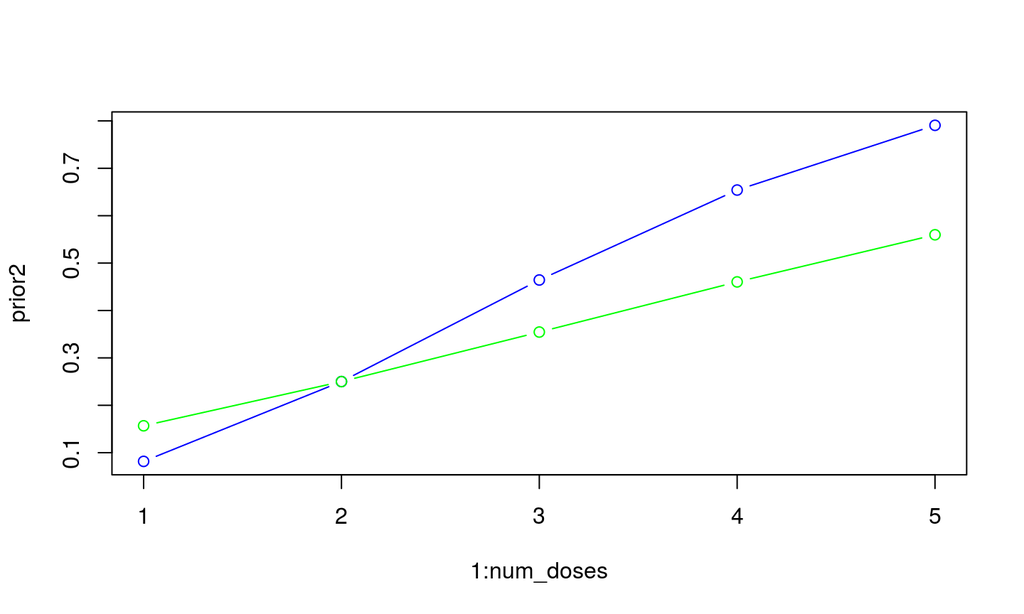

```r
prior1 = getprior(halfwidth = 0.05, target = target, nu = 2, nlevel = num_doses)
prior2 = getprior(halfwidth = 0.1, target = target, nu = 2, nlevel = num_doses)
plot(1:num_doses, prior2, type = 'b', col = 'blue')
points(1:num_doses, prior1, type = 'b', col = 'green')
```

## The same graph but prettier

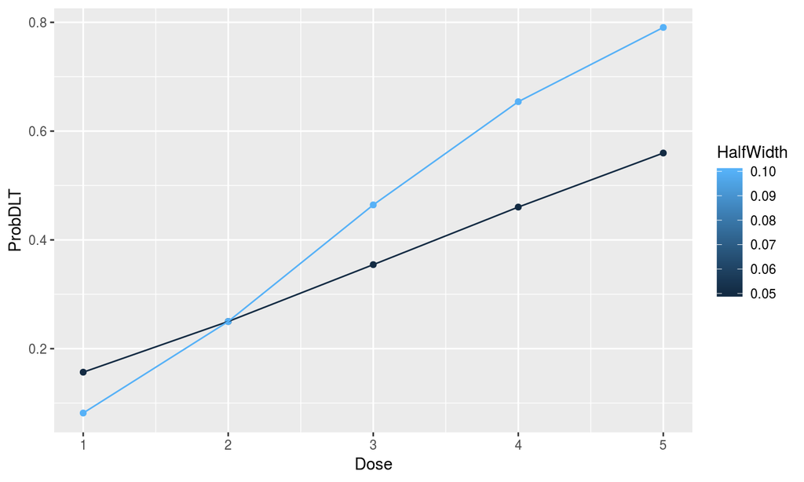

```r
bind_rows(data.frame(Dose = 1:num_doses, ProbDLT = prior1, HalfWidth = 0.05),
          data.frame(Dose = 1:num_doses, ProbDLT = prior2, HalfWidth = 0.1)) %>%
  ggplot(aes(x = Dose, y = ProbDLT, group = HalfWidth, col = HalfWidth)) +
  geom_point() + geom_line()
```

## Task

Choose a half-width (somewhere between 0.05 and 0.1) and keep it fixed.

Create five priors that in-turn assume that dose-levels 1,…,5 are the correct dose.

Plot the five priors together. Use colour to distinguish them.

## Solution

```r
prior1 = getprior(halfwidth = 0.1, target = target, nu = 1, nlevel = num_doses)
prior2 = getprior(halfwidth = 0.1, target = target, nu = 2, nlevel = num_doses)
prior3 = getprior(halfwidth = 0.1, target = target, nu = 3, nlevel = num_doses)
prior4 = getprior(halfwidth = 0.1, target = target, nu = 4, nlevel = num_doses)
prior5 = getprior(halfwidth = 0.1, target = target, nu = 5, nlevel = num_doses)

priors_data = bind_rows(
  data.frame(Dose = 1:num_doses, ProbDLT = prior1, Guess = 1),
  data.frame(Dose = 1:num_doses, ProbDLT = prior2, Guess = 2),
  data.frame(Dose = 1:num_doses, ProbDLT = prior3, Guess = 3),
  data.frame(Dose = 1:num_doses, ProbDLT = prior4, Guess = 4),
  data.frame(Dose = 1:num_doses, ProbDLT = prior5, Guess = 5)
) %>% mutate(Guess = factor(Guess))
```

## Solution (cont)

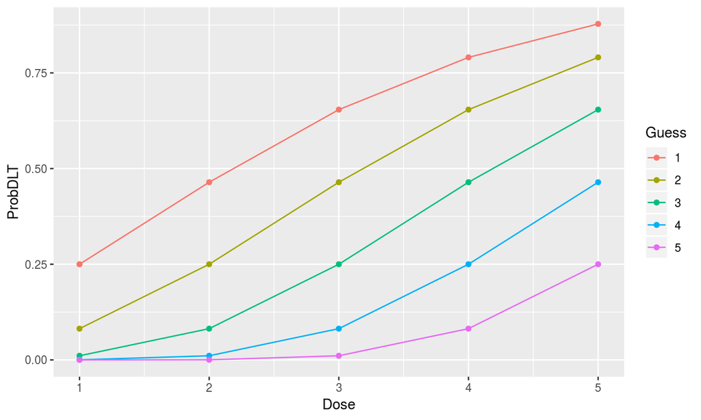

```r
priors_data %>%
  ggplot(aes(x = Dose, y = ProbDLT, group = Guess, col = Guess)) +
  geom_point() + geom_line()
```

## The prior on \(\beta\)

By default in `dfcrm`, it takes the prior \(\beta \sim N(0, 1.34)\).

Keeping the mean fixed at 0 is fine - why?

(Recall that the model is \(F(x, \beta) = x^{\exp{(\beta)}}\))

The prior SD of \(\beta\) determines how much the skeleton may be raised or lowered.

You can specify an alternative SD using the `scale` parameter in `crm`.

## Effect of prior on \(\beta\)

Contrast these models fit to 2NNN 3TNT

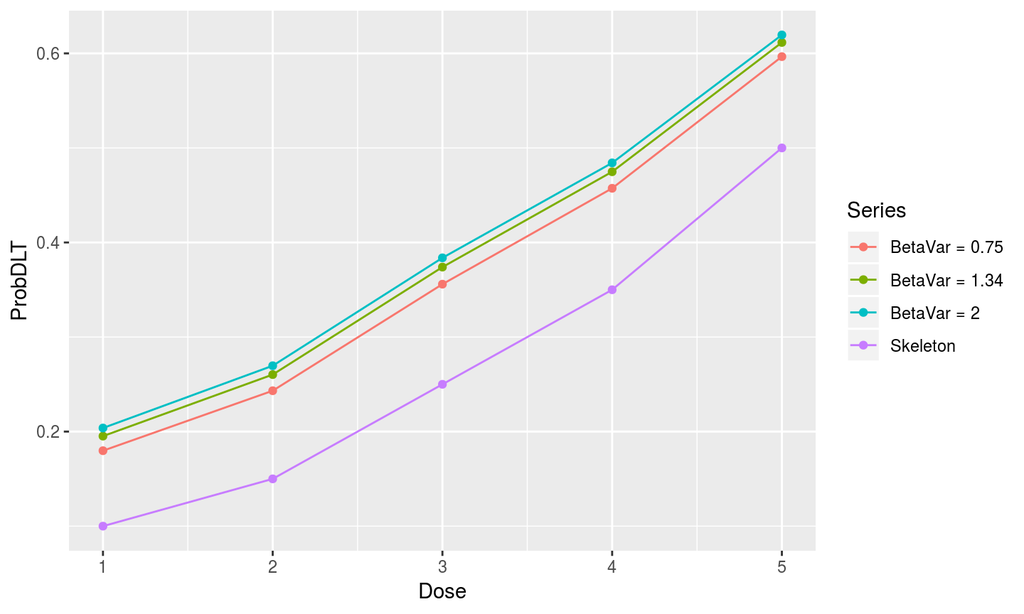

The tighter prior on \(\beta\) hugs the posterior closer to the skeleton.

## The mathematics behind the scene

## Bayesian updating

Let \(Y_i\) be a random variable taking values \(\left\{0, 1\right\}\) representing the presence or absence of DLT in patient \(i\).

Let \(x_i\) be the dose given to patient \(i\).

Evaluating the outcomes and doses for \(i\) patients, the likelihood of \(\beta\) is

\[ L_i(\beta) = \prod_{j=1}^i \left\{ F(x_j, \beta) \right\}^{Y_j} \left\{ 1 - F(x_j, \beta) \right\}^{1-Y_j} \]

## Posterior mean of \(\beta\)

Let \(\beta\) have prior \(f(\beta)\).

The posterior expected value for \(\beta\) after the evaluation of \(i\) patients is

\[ \hat{\beta}_i = \frac{\int_{-\infty}^\infty \beta f(\beta)L_i(\beta) d\beta}{\int_{-\infty}^\infty f(\beta)L_i(\beta) d\beta} \]

## Plug in estimate for posterior Prob(DLT)

In `dfcrm`, the estimate \(\hat{\beta}_i\) is plugged into \(F(x, \beta)\) to estimate the posterior Prob(DLT) curve. Regardez! \(\hat{\beta}_i\) is

```r
fit7$estimate
```

```
## [1] -0.3698421
```

```r
fit7$ptox
```

```
## [1] 0.2037777 0.2696548 0.3837698 0.4841974 0.6194916
```

```r
skeleton^exp(fit7$estimate)
```

```
## [1] 0.2037777 0.2696548 0.3837698 0.4841974 0.6194916
```

## Numerically deriving \(\hat{\beta}_i\)

The posterior distribution of \(\beta\) is proportional to \(f(\beta)L_i(\beta)\).

Assume we observed 2NNN 3TNT

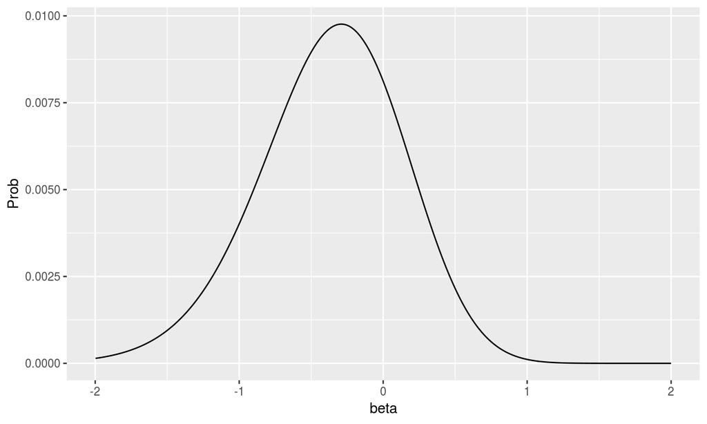

## Sample representative points on the x-axis

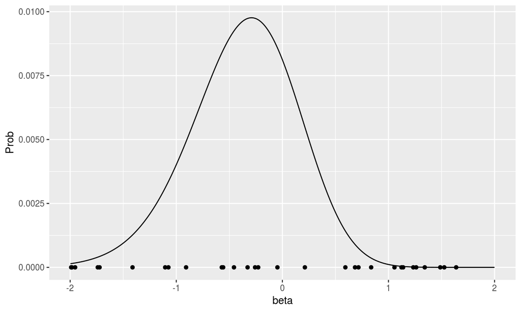

## Evaluate function at those points

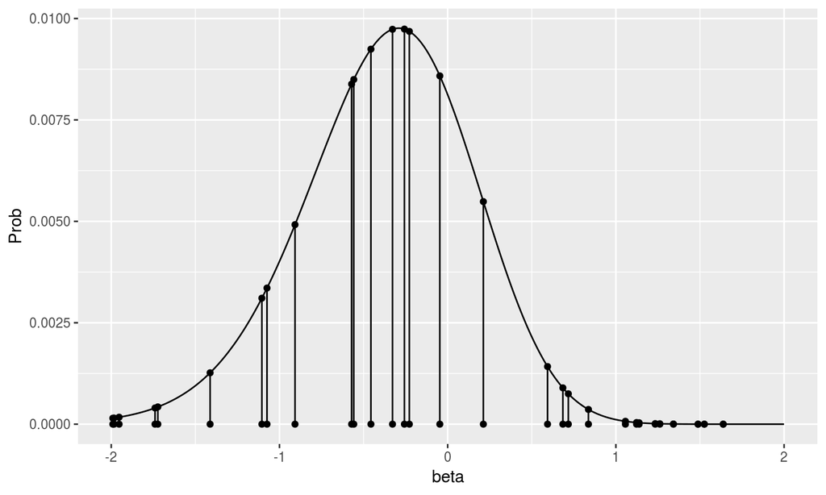

## Calcuate their mean

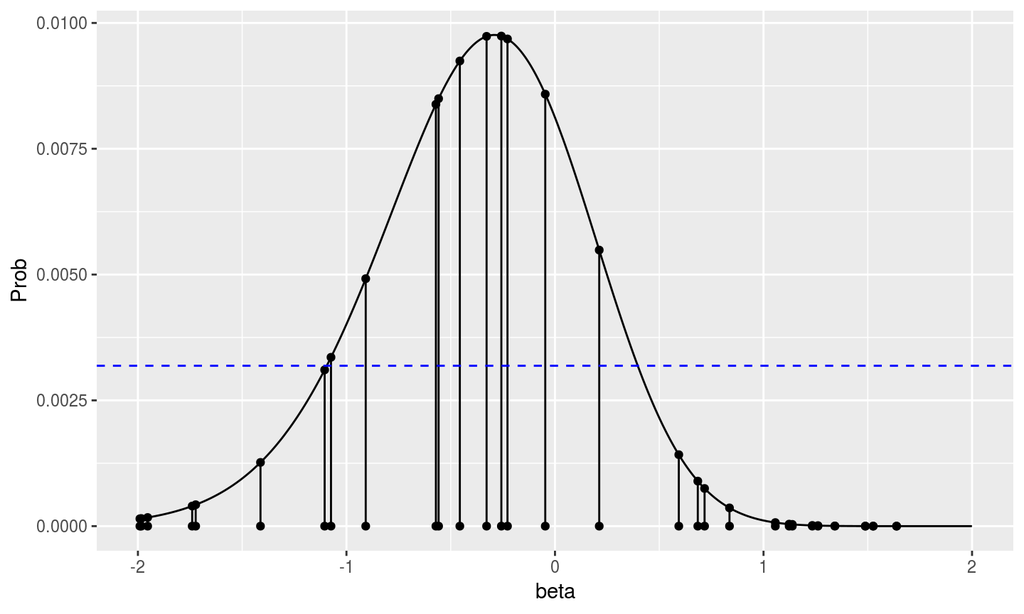

The integral is approximated by mean \(\times\) width of region

## How good is this estimate?

With 1000 points on the x-axis:

```r
mean(beta_samp * g_samp) / mean(g_samp)
```

```
## [1] -0.3542402
```

```r
fit7$estimate
```

```
## [1] -0.3698421
```

Pretty close. Use more points and it will get closer.

## Why use the plug-in method?

Tractability. Calculating the posterior mean of \(\beta\) is simple, as we have seen, and much simpler than sampling from its posterior distribution.

## Why not use the plug-in method?

Because full Bayesian inference is better in so many ways.

But it requires Stan.

We will save that for next time.

## Conclusions

## You have learned:

- How the empiric CRM shifts a pre-specified skeleton to observed data
- To fit the empiric and logistic subtypes of CRM to observed data using `dfcrm`
- To generate decent priors immediately using `getprior`
- The effect on inference of priors on \(\beta\)
- How to estimate the posterior mean of \(\beta\) using basically any language
- And how to use this plus-in mean to estimate the posterior Prob(DLT) curve
- …Which is the basis of dose-recommendations.

## Next steps

- To do really nice inference, you need full Bayesian sampling
- How to select parameters for performance using simulation studies
- Trial planning and parameterisation-honing using dose-transition pathways

## Thanks

Kristian Brock, PhD

Principal Statistician

CRCTU

University of Birmingham

k.brock@bham.ac.uk